# Welcome to Nightvale Text Analysis

William Lovejoy

7/12/2022

As practice in scraping multiple webpages, and in analyzing multiple related texts, I decided to collect and analyze all transcripts for the “Welcome to Nightvale” podcast. The transcripts are available through their main site: link.

```r
library(rvest)
library(tidyverse)
library(tidytext)
library(gridExtra)
library(cowplot)
```

As always, we load in our libraries. We’ll be using rvest for scraping, and the others for analysis and visualization.

### Scraping Data

```r
counter = 2012
new_urls = "http://www.nightvalepresents.com/welcome-to-night-vale-transcripts?year=%s"
i = 1
w = 1
all_frames <- list()

while(counter < 2023){
  home <- read_html(sprintf(new_urls, counter))
  links <- home %>%
    html_nodes(".entry-title") %>%
    html_nodes("a") %>%
    html_attr("href") %>%
    xml2::url_absolute("https://www.nightvalepresents.com/welcome-to-night-vale-transcripts")
  links <- rev(links)
  for(x in 1:length(links)){
    script <- read_html(links[x]) %>%
      html_nodes("p+ p") %>%
      html_text()
    df <- data.frame(Episode = i,
                     Relative_Episode = w,
                      Year = counter,
                      Transcript = seq(1:length(script)))
    df$Transcript <- script
    all_frames[[i]] <- df
    i = i+1
    w = w + 1
  }
  counter = counter + 1
  w = 1
}

nightvale <- bind_rows(all_frames)
```

This section loads in the base url for the podcast transcripts. However, this page itself doesn’t have the transcripts itself. Instead it contains links to individual pages, with one transcript per page. We use a while loop to go through the page for a given year and save the links into a list. It then uses a for loop to pass through that list, taking the year produced, the base episode number, the relative episode (starting from 1 each new year), and the transcript for the episode. It’s important to note that the transcripts are only available in paragraphs, so each row is a new paragraph. Once a dataframe is created, it’s added to a list. After exiting the loop, we can bind all the dataframes together into one large one to work on.

### Tokens

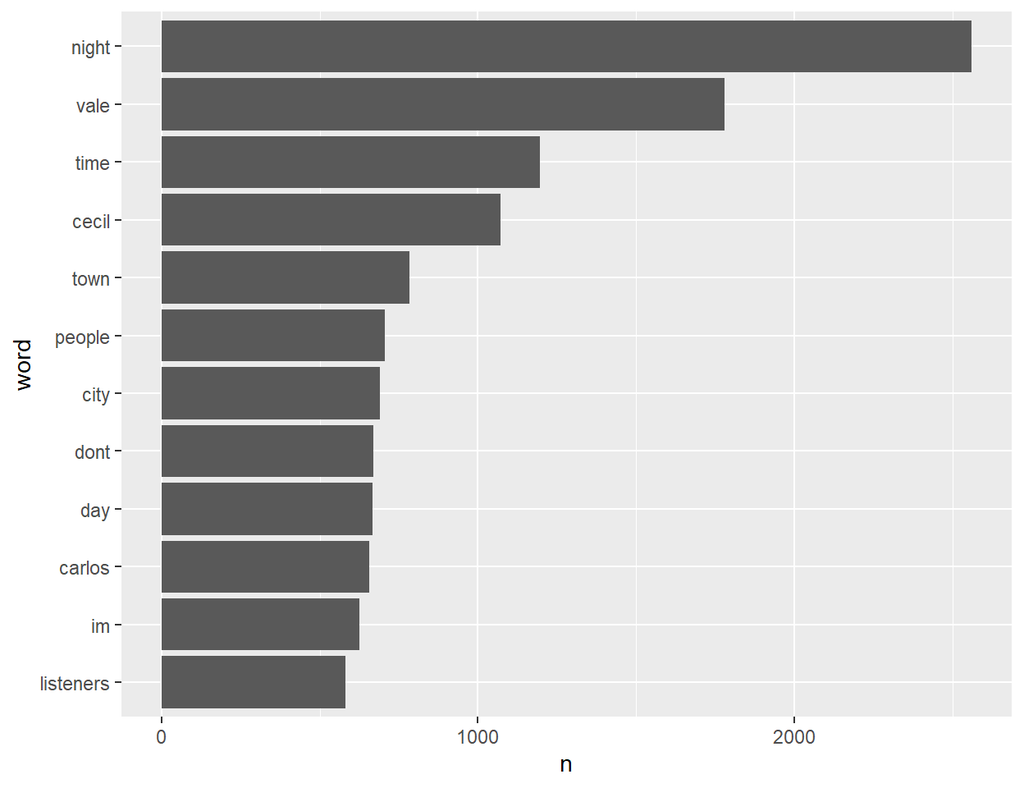

```r
tidy_vale<- nightvale %>%
  unnest_tokens(word, Transcript) %>%
  mutate(word = gsub("’", "", word)) %>%
  anti_join(stop_words)

tidy_vale <- subset(tidy_vale, !grepl("[^a-zA-Z]", word))

tidy_vale %>%
  count(word, sort = TRUE) %>%
  filter(n > 500) %>%
  mutate(word = reorder(word, n))%>%
  ggplot(aes(x = n, y = word)) + geom_col()
```

```r
annual_bigrams <- nightvale %>%
  group_by(Year) %>%
  unnest_tokens(bigrams, Transcript, token = "ngrams", n = 2) %>%
  separate(bigrams, c("word1", "word2"), sep = " ") %>%
  filter(!word1 %in% stop_words$word,
         !word2 %in% stop_words$word,
         is.na(word1) == FALSE,
         is.na(word2) == FALSE,
         !grepl("[^a-zA-Z]", word1),
         !grepl("[^a-zA-Z]", word1)) %>%
  count(word1, word2, sort = TRUE) %>%
  ungroup() %>%
  unite(bigrams, word1, word2, sep = " ")
```

Throughout the entire podcast, the two most important words are “night” and “vale”. Which makes sense, as they’re in the name of the show. Other key words in this list are “cecil” (which is the name of the narrator), “carlos” (who is a love interest for the narrator), and “listeners” (because the podcast is done as a radio show broadcast in the small southwestern town of Nightvale).

```r
nightvale_bigrams <- nightvale %>%
  unnest_tokens(bigrams, Transcript, token = "ngrams", n = 2) %>%
  separate(bigrams, c("word1", "word2"), sep = " ") %>%
  filter(!word1 %in% stop_words$word,
         !word2 %in% stop_words$word,
         is.na(word1) == FALSE,
         is.na(word2) == FALSE,
         !grepl("[^a-zA-Z]", word1),
         !grepl("[^a-zA-Z]", word1)) %>%
  count(word1, word2, sort = TRUE) %>%
  unite(bigrams, word1, word2, sep = " ")

all_bg <- nightvale_bigrams %>%
  filter(n > 75) %>%
  ggplot(aes(x = n, y = reorder(bigrams, n))) + geom_col() +
  labs(title = "Bigram Counts in All Episodes", x = "n", y = "Bigram")
```

While our individual tokens gave us a glimpse at the more common topics, using bigrams helps us get a more specific idea of what the texts talk about. “night vale” is still the most common, but that’s not particularly surprising. Of more significant note are the phrases “city council”, “secret police”, and “dog park”. While the city council and Sheriff’s secret police are long term topics of the show, the dog park is less of one. It was part of the pilot episode, with the first mention reading:

> The City Council announces the opening of a new dog park at the corner of Earl and Summerset, near the Ralphs. They would like to remind everyone that dogs are not allowed in the dog park. People are not allowed in the dog park. It is possible you will see hooded figures in the dog park. Do not approach them. Do not approach the dog park. The fence is electrified and highly dangerous. Try not to look at the dog park and especially do not look for any period of time at the hooded figures. The dog park will not harm you.

After which the narrator described it as a mysterious place where interns vanished, the mangled remains of prehistoric creatures could be found near, and that may or may not emit a static-y hum that is actually a coded message from an “unearthly voice” urging citizens to bring precious metals and toddlers to the dog park.

```r
nightvale_2012 <- annual_bigrams %>%
  filter(Year == "2012")

graph2012 <- nightvale_2012 %>%
  head(5)  %>%
  ggplot(aes(x= n, y = reorder(bigrams,n))) + geom_col(fill = "darkgreen") +
  labs(title = "2012 Bigrams", y = "Bigrams")
```

In order to graph the most important bigrams for each year of the podcast, we need to filter out each year, sort it, take the top handful (5 in this case), and create a saved graph. I did this for all 11 years of the show, then used plot_grid to make the following plot.

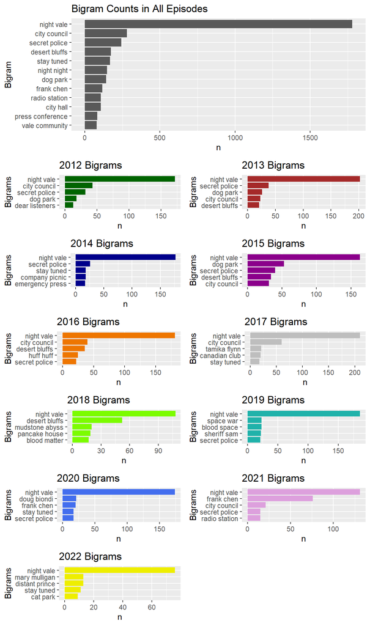

```r
bigrams_by_year <- plot_grid(graph2012, graph2013, graph2014, graph2015, graph2016, graph2017,
             graph2018, graph2019, graph2020, graph2021, graph2022,
             nrow = 6, ncol = 2)

plot_grid(all_bg, bigrams_by_year, nrow = 2, rel_heights = c(1/4, 3/4))
```

```r
nightvale_tf <- nightvale %>%
  unnest_tokens(word, Transcript) %>%
  mutate(word = gsub("’", "", word)) %>%
  anti_join(stop_words) %>%
  add_count(Year, name = "Total_Words") %>%
  group_by(Year, Total_Words) %>%
  count(word, sort = TRUE)

nightvale_tf <- subset(nightvale_tf, !grepl("[^a-zA-Z]", word))


nightvale_tf_idf <- nightvale_tf %>%
  bind_tf_idf(word, Year, n) %>%
  arrange(desc(tf_idf))

yearly_tf <- nightvale_tf_idf %>%
  group_by(Year) %>%
  top_n(10) %>%
  ungroup() %>%
  facet_bar(y = word, x = tf_idf, by = Year, nrow = 6)

all_tf <- nightvale_tf_idf %>%
  slice_max(11, with_ties = FALSE) %>%
  ggplot(aes(x = tf_idf, y = reorder(word, tf_idf))) + geom_col() +
  labs(title = "'Welcome to Nightvale' TF-IDF",x = "", y = "Word")
```

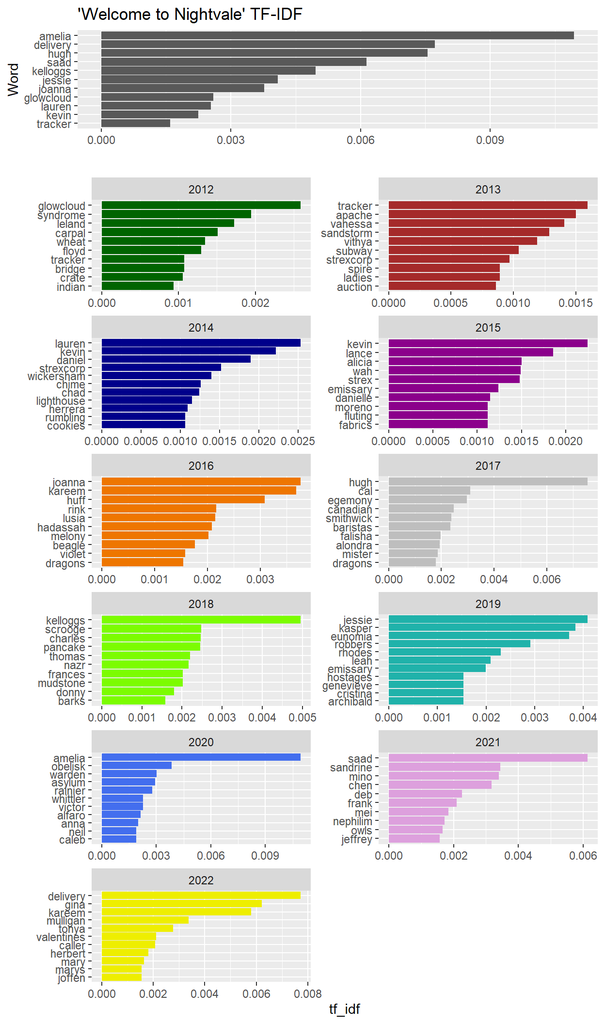

```r
plot_grid(all_tf, yearly_tf, nrow = 2, rel_heights = c(1/6, 5/6))
```

```r
nightvale_bigrams_tf <- nightvale %>%
  unnest_tokens(bigrams, Transcript, token = "ngrams", n = 2) %>%
  separate(bigrams, c("word1", "word2"), sep = " ") %>%
  filter(!word1 %in% stop_words$word,
         !word2 %in% stop_words$word,
         is.na(word1) == FALSE,
         is.na(word2) == FALSE,
         !grepl("[^a-zA-Z]", word1),
         !grepl("[^a-zA-Z]", word1)) %>%
  unite(bigrams, word1, word2, sep = " ") %>%
  add_count(Year, name = "Total_Words") %>%
  group_by(Year, Total_Words) %>%
  count(bigrams, sort = TRUE)

nightvale_bigrams_tf<- nightvale_bigrams_tf %>%
  bind_tf_idf(bigrams, Year, n) %>%
  arrange(desc(tf_idf))

all_bgs_tf <- nightvale_bigrams_tf %>%
  slice_max(tf_idf, n= 2, with_ties = FALSE) %>%
  ggplot(aes(x = tf_idf, y = reorder(bigrams, tf_idf))) + geom_col() +
  labs(title = "'Welcome to Nightvale' Bigram TF-IDF", x = "",
       y = "Bigrams")

yearly_bgs_tf <- nightvale_bigrams_tf %>%
  group_by(Year) %>%
  slice_max(tf_idf, n= 10, with_ties = FALSE) %>%
  ungroup() %>%
  facet_bar(y = bigrams, x = tf_idf, by = Year, nrow = 6)
```

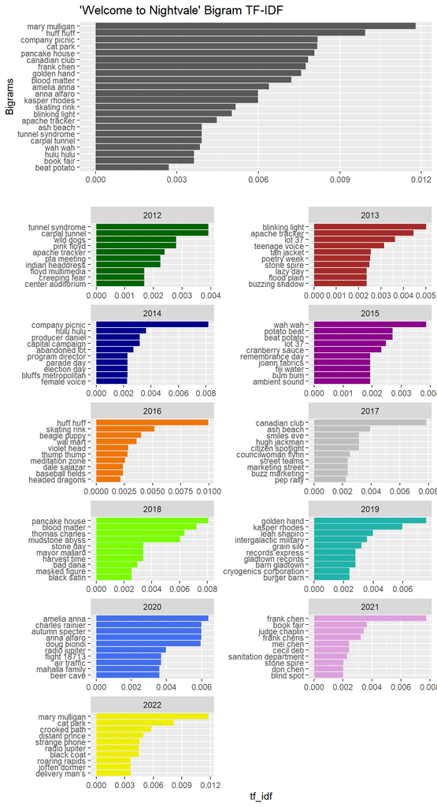

```r
plot_grid(all_bgs_tf, yearly_bgs_tf, nrow = 2, rel_heights = c(1/4, 3/4))
```

### Sentiments

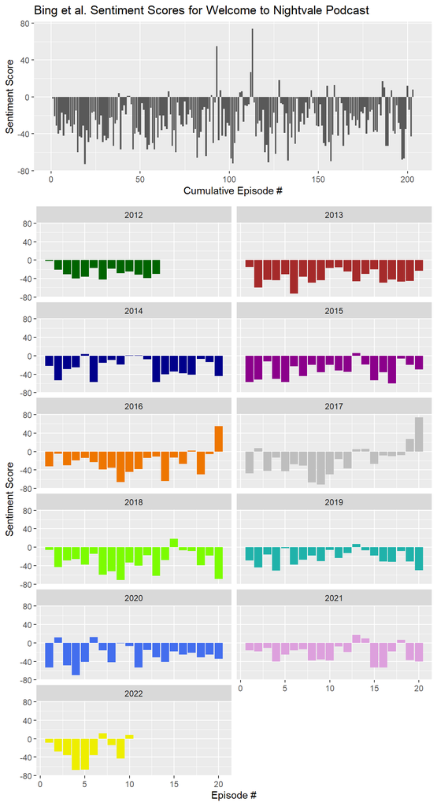

```r
tidy_vale_sentiments <- tidy_vale %>%
  inner_join(get_sentiments("bing")) %>%
  count(index = Episode, sentiment) %>%
  pivot_wider(names_from = sentiment, values_from = n, values_fill = 0) %>%
  mutate(sentiment = positive - negative)

all_s <- tidy_vale_sentiments %>%
  ggplot(aes(x = index, y = sentiment)) +
  geom_col(show.legend = FALSE) +
  labs(title = "Bing et al. Sentiment Scores for Welcome to Nightvale Podcast",
       x = "Cumulative Episode #", y = "Sentiment Score")


annual_sentiments <- tidy_vale %>%
  group_by(Year) %>%
  inner_join(get_sentiments("bing")) %>%
  count(index = Relative_Episode, sentiment) %>%
  pivot_wider(names_from = sentiment, values_from = n, values_fill = 0) %>%
  mutate(sentiment = positive - negative)

year_s <- annual_sentiments %>%
  ggplot(aes(x = index, y = sentiment, fill = factor(Year), group = Year)) +
  geom_col(show.legend = FALSE) +
  scale_fill_manual(values = colors) +
  labs(x = "Episode #", y = "Sentiment Score") +
  facet_wrap(~Year, nrow = 6)

plot_grid(all_s, year_s, nrow = 2,  rel_heights = c(1/4, 3/4))
```

We can see here that the overall sentiment of the show is negative. It makes sense when looking at the overall themes and genres of the show though. The podcast is classified as horror fiction, meaning overall darker tones. It also edges into the genre of cosmic horror, which functions as a subgenere of horror fiction that empahsizes the horror of the incomprehensible and unknowable instead of gore or shock. Works in this genre tend to emphasize themes of cosmic dread, forbidden/dangerous knowledge, madness, and non human-influences on religion, superstition, humanity, and fate. All of these are topics that we affix a negative sentiment to, so it seems obvious that a radio show that uses all of these themes would contain words with a larger negative sentiment.